# ¶ Análisis del mercado peruano de mascotas antes y durante la pandemia ¶

14/12/2021

# **1. Introducción**

## 1.1. Importancia

Para el 2019 “el 60% de peruanos tenía al menos una mascota en casa” según el [*CPI*](https://www.ue.edu.pe/mails/2021/ue/img/8-De-pelos-y-patas-la-industria-mantiene-una-tendencia-creciente-que-ha-abierto-las-puertas-a-servicios-y-productos-que-hace-10-a%C3%B1os.pdf). Sin embargo, al llegar la pandemia muchos negocios tuvieron grandes perdidas o cerraron a excepción de algunos que encontraron la manera de sacarle provecho a la situación. Es en este contexto de incertidumbre que nos interesa saber qué paso con el negocio de las mascotas. El cual, previo a la pandemia venía con una tendencia creciente.

## 1.2. Justificación

Es factible pues la recolección de datos se da mediante encuestas a través de Google forms y con preguntas orientadas a los objetivos. Asimismo, con respecto a la originalidad el proyecto esta hecho desde la recolección de datos por nosotros.

# **2. Objetivos**

## 2.1. Objetivo General

Analizar el comportamiento del mercado peruano de mascotas y los cambios provocados por la pandemia

## 2.2. Objetivos específicos

1. Describir el crecimiento del mercado de mascotas.
2. Identificar los sectores del mercado de mascotas en el que los dueños gastan más.
3. Establecer los sectores del mercado en el que los dueños gastan menos.
4. Identificar las marcas con mayor posición en el mercado.
5. Determinar la relación entre el nivel de dedicación y tiempo con el dinero invertido en las mascotas.

# **3. Marco Teórico**

- **Tema delimitado:** Análisis del mercado peruano de mascotas antes y durante la pandemia [2019-2021]
- **Población objetivo:** Personas peruanas con al menos una mascota
- **Tipo de muestreo:** Muestreo Aleatorio Simple (MAS)
- **Sesgo:** Sesgo de pertenencia y prevalencia
- **Unidades muestrales:** 151
- **Interesados:**
  - Empresas de mascotas
  - Público interesado en saber el comportamiento del mercado de mascotas

Observaciones: Dado que se ha optado por elegir como ingreso de la data a la encuesta, toda nuestra población objetiva tiene la misma probabilidad de ser parte de la investigación. Por lo cual se da un muestreo aleatorio simple, sin embargo es posible que a la hora de recolectar los datos se den el sesgo de pertenencia y prevalencia. El primero porque al ser nosotros los que compartimos las encuestas a nuestros contactos la mayor parte de las respuestas van a tender a ser parte del grupo los estudiantes de UTEC; lo que podría darles una mayor representatividad. El segundo sesgo se puede dar debido a que el formulario solo registra las encuestas una vez que todas las preguntas sean respondidas, pero pueden haber participantes que no llegaron a responder todas las preguntas y se retiraron.

# **4. Limpieza de datos**

Las consideraciones para la eliminación de datos fueron:

- Información sin sentido
- Falta de claridad de la información
- Información contradictoria

## 4.1. Asignación de variables

```
##  [1] "MarcTem"       "CorreoElec"    "Punt"          "AP_ESTADO"
##  [5] "AP_NUM"        "AP_TIP_MASQ"   "AP_SEC_COST"   "AP_COST_ALI"
##  [9] "AP_COST_VET"   "AP_COST_JYA"   "AP_COST_LIM"   "AP_COST_MED"
## [13] "AP_MARCA_ALI"  "AP_MARCA_J"    "AP_MARCA_LIM"  "AP_MARCA_MED"
## [17] "AP_HORAS_MASQ" "AP_DIF_PRYSRV" "AP_MOT_DIF"    "DP_ADOP_COM"
## [21] "DP_CANT_MASQ"  "DP_NUM_MASQ"   "DP_MASQ_AHORA" "DP_TIP_MASQ"
## [25] "DP_SEC_COST"   "DP_COST_ALI"   "DP_COST_VET"   "DP_COST_JYA"
## [29] "DP_COST_LIM"   "DP_COST_MED"   "DP_MARCA_ALI"  "DP_MARCA_J"
## [33] "DP_MARCA_LIM"  "DP_MARCA_MED"  "DP_HORAS_MASQ" "DP_DIF_PRYSRV"
## [37] "DP_MOT_DIF"
```

## 4.2. Error de precisión

```r
desvia<-sd(DF$AP_NUM, na.rm = T)
```

```r
errorpreci(0.95,desvia,150)
```

```
## [1] 0.4811347
```

```r
cantmuestra<-c(1:200)
ejeb<-c(0.01:0.20)
```

```r
ErrordePrecision <- errorpreci(0.95,desvia,1:200)
```

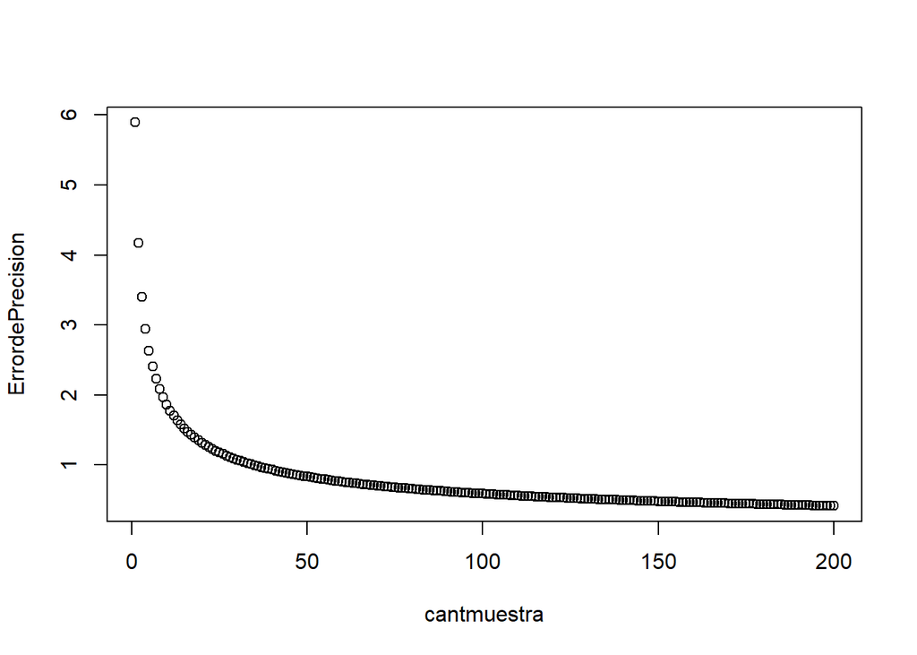

```r
plot(cantmuestra,ErrordePrecision)
```

Podemos concluir a través de la gráfica anterior que a medida que el Error de Precisión es más pequeño, la cantidad necesaria para cumplir con el mínimo de personas encuestadas es mayor.

# **5. Variables**

**Tabla de clasificación de Variables**

*Antes de la pandemia*

| Pregunta | Variable | Tipo de Variable | Restricciones |
| --- | --- | --- | --- |
| Contabas con una mascota en casa | AP_ESTADO | Nominal | Si o No (Tipo Booleano) |
| ¿Cuántas mascotas tenías antes de la pandemia? | AP_NUM | Discreta | Entero no negativo |
| ¿Qué tipo(s) de mascota(s)? | AP_TIP_MASQ | Nominal | Perro, gato, hamster, cuyes, canario, loro, rana, iguana, araña/ tarántula |
| ¿En qué sector gastaba más dinero? | AP_SEC_COST | Nominal | Alimentación, Veterinario, Juguetes y accesorios, Limpieza o medicina |
| ¿Mensualmente cuánto gastaba aproximadamente en la alimentación de su mascota? | AP_COST_ALI | Continua | Número no negativo |
| ¿Mensualmente cuánto gastaba aproximadamente en las visitas al veterinario de su mascota? | AP_COST_VET | Continua | Número no negativo |
| ¿Anualmente cuánto gastaba aproximadamente en los juguetes y accesorios de su mascota? | AP_COST_JYA | Continua | Número no negativo |
| ¿Mensualmente cuánto gastaba aproximadamente en la limpieza de su mascota? | AP_COST_LIM | Continua | Número no negativo |
| Si antes de la pandemia su mascota necesitaba medicamentos ¿Mensualmente cuánto gastaba aproximadamente en estas medicinas? | AP_COST_MED | Continua | Número no negativo |
| ¿Qué marca usa más para la alimentación de su mascota? | AP_MARCA_ALI | Nominal | Empresas formales dedicadas a las mascotas |
| ¿Qué marca usa más para los juguetes de su mascota? | AP_MARCA_J | Nominal | Empresas formales dedicadas a las mascotas |
| ¿Qué marca usa más para la limpieza de su mascota? | AP_MARCA_LIM | Nominal | Empresas formales dedicadas a las mascotas |
| Si su mascota tomaba medicinas antes de la pandemia ¿Qué marca usa más para estas? | AP_MARCA_MED | Nominal | Empresas formales dedicadas a las mascotas |
| ¿Cuántas horas al día aproximadamente pasaba con su mascota antes de la pandemia? | AP_HORAS_MASQ | Continua | Número no negativo no mayor de 24 |
| Si antes de la pandemia no pudo o tuvo dificultades para conseguir algún producto o servicio para su mascota márquelos | AP_DIF_PRYSRV | Nominal | No tengo dificultades, Alimentación, Veterinario, Juguetes y accesorios, Limpieza o medicina |
| Marque los motivos por los que no pudo o fue difícil conseguir el producto o servicio | AP_MOT_DIF | Nominal | No tengo problemas para conseguir productos/servicios, Precios elevados, Pocos productos/ servicios, Tipo de mascota poco común, No venden/brindan el producto/servicio en mi país, Mala calidad |

*Durante la pandemia*

| Pregunta | Variable | Tipo de Variable | Restricciones |
| --- | --- | --- | --- |
| Durante la pandemia adoptaste o compraste una mascota | DP_ADOP_COM | Nominal | Adopte, Compre, Ninguna de las anteriores |
| ¿Cuántas mascotas adoptaste/compraste? | DP_CANT_MASQ | Discreta | Entero no negativo |
| ¿Tienes mascotas ahora? | DP_NUM_MASQ | Nominal | Si, No |
| ¿Cuántas mascotas tienes ahora? | DP_MASQ_AHORA | Discreta | Entero no negativo |
| ¿Qué tipo(s) de mascota(s)? | DP_TIP_MASQ | Nominal | Perro, gato, hamster, cuyes, canario, loro, rana, iguana, araña/ tarantula |
| ¿En qué sector gastas más dinero? | DP_SEC_COST | Nominal | Alimentación, Veterinario, Juguetes y accesorios, Limpieza o medicina |
| ¿Mensualmente cuánto gasta aproximadamente en la alimentación de su mascota? | DP_COST_ALI | Continua | Número no negativo |
| ¿Mensualmente cuánto gasta aproximadamente en las visitas al veterinario de su mascota? | DP_COST_VET | Continua | Número no negativo |
| ¿Anualmente cuánto gasta aproximadamente en los juguetes y accesorios de su mascota? | DP_COST_JYA | Continua | Número no negativo |
| ¿Mensualmente cuánto gasta aproximadamente en la limpieza de su mascota? | DP_COST_LIM | Continua | Número no negativo |
| Si antes de la pandemia su mascota necesitaba medicamentos ¿Mensualmente cuánto gasta aproximadamente en estas medicinas? | DP_COST_MED | Continua | Número no negativo |
| ¿Qué marca usa más para la alimentación de su mascota? | DP_MARCA_ALI | Nominal | Empresas formales dedicadas a las mascotas |
| ¿Qué marca usa más para los juguetes de su mascota? | DP_MARCA_J | Nominal | Empresas formales dedicadas a las mascotas |
| ¿Qué marca usa más para la limpieza de su mascota? | DP_MARCA_LIM | Nominal | Empresas formales dedicadas a las mascotas |
| Si su mascota tomaba medicinas antes de la pandemia ¿Qué marca usa más para estas? | DP_MARCA_MED | Nominal | Empresas formales dedicadas a las mascotas |
| ¿Cuántas horas al día pasa con su mascota? | DP_HORAS_MASQ | Continua | Número no negativo no mayor de 24 |
| Si no puede o tiene dificultades para conseguir algún producto o servicio para su mascota márquelos | DP_DIF_PRYSRV | Nominal | No tengo dificultades, Alimentación, Veterinario, Juguetes y accesorios, Limpieza o medicina |
| Marque los motivos por los que no pudo o fue difícil conseguir el producto o servicio | DP_MOT_DIF | Nominal | No tengo problemas para conseguir productos/servicios, Precios elevados, Pocos productos/ servicios, Tipo de mascota poco común, No venden/brindan el producto/servicio en mi país, Mala calidad |

# **6. Intervalos de confianza**

En el caso de nuestra base de datos, establecemos que los parámetros para los intervalos de confianza para las medias de las variables numéricas continuas a considerar son los siguientes:

- **Nivel de confianza:** 95%
- **Significancia:** α=0.05
- **Tamaño de la muestra:** 151

Además, considerando que nuestro número de muestra es mayor a 30 y poseemos una desviación estándar desconocida. Podemos usar una distribución normal.

# **7. Descriptores numéricos y gráficos**

## 7.1. Describir el crecimiento del mercado de mascotas

Analizar como varían el número de dueños y el total de mascotas.

Personas con mascotas antes y durante la pandemia

```
## [1] 100
```

```
## [1] 107
```

Cantidad de mascotas antes y durante la pandemia

```
## [1] 202
```

```
## [1] 238
```

Media aritmética de la cantidad de mascotas antes y durante la pandemia

```
## [1] 2.040404
```

```
## [1] 2.224299
```

Mediana de la cantidad de mascotas antes y durante la pandemia

```
## [1] 1
```

```
## [1] 2
```

Cantidad de personas con cierto numero de mascotas antes de la pandemia

| 1 | 2 | 3 | 4 | 5 | 6 | 30 |
| --- | --- | --- | --- | --- | --- | --- |
| 50 | 31 | 11 | 4 | 1 | 1 | 1 |

Cantidad de personas con cierto numero de mascotas durante la pandemia

| 1 | 2 | 3 | 4 | 5 | 8 | 30 |
| --- | --- | --- | --- | --- | --- | --- |
| 53 | 27 | 12 | 8 | 5 | 1 | 1 |

Observaciones:

**Variación de los gastos totales mensuales**

Utilizaremos el gráfico de cajas y bigotes para comparar los gastos totales antes y durante la pandemia

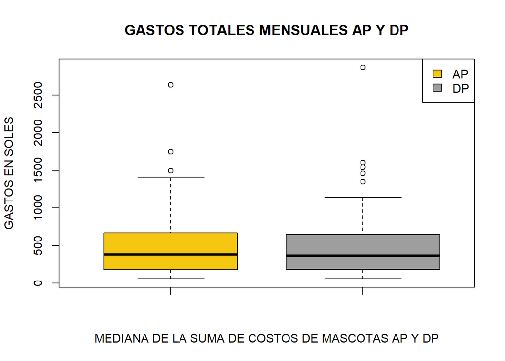

Calculamos los ejes de los intervalos de confianza:

| i | lim_infG1 | mediaG1 | lim_supG1 |
| --- | --- | --- | --- |
| Antes de Pandemia | 412.34 | 513.48 | 614.62 |
| Después de Pandemia | 397.45 | 481.46 | 565.47 |

Observaciones: La concentración de datos sobre los gastos AP (antes de la pandemia) y DP (durante la pandemia) no cambiaron en gran medida, esto podría tratarse del aumento de algunos gastos y la disminución de otros.

## 7.2. Identificar los sectores del mercado de mascotas donde las personas gastan más dinero

Antes de la pandemia

| Alimentación | Juguetes y accesorios | Limpieza | Medicina | Veterinario |
| --- | --- | --- | --- | --- |
| 66 | 2 | 3 | 2 | 27 |

Durante la pandemia

| Alimentación | Juguetes y accesorios | Limpieza | Medicina | Veterinario |
| --- | --- | --- | --- | --- |
| 81 | 2 | 4 | 3 | 17 |

*Antes de la pandemia*

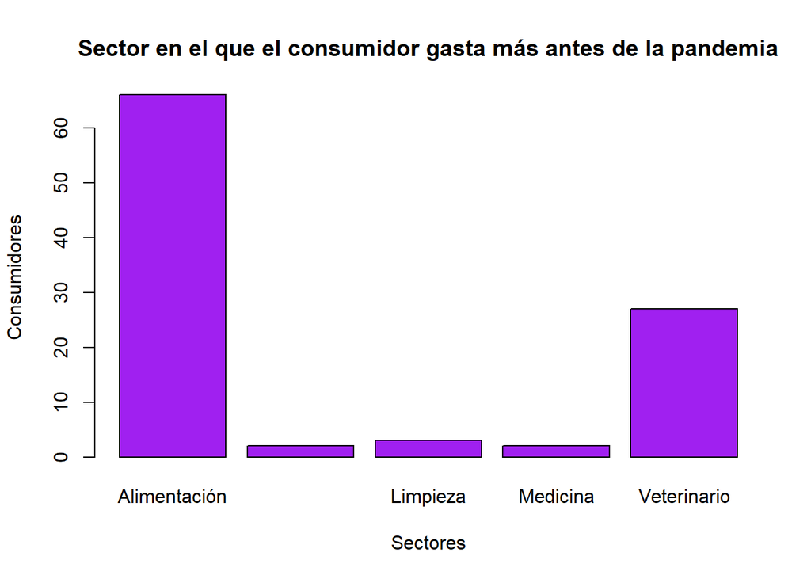

Calculamos los ejes de los intervalos de confianza del gráfico anterior:

| SectoresAP | lim_infG2 | mediaG2 | lim_supG2 |
| --- | --- | --- | --- |
| Alimentación | 105.34 | 124.97 | 144.60 |
| Juguetes y accesorios | 100.98 | 163.59 | 226.20 |
| Limpieza | 49.43 | 68.85 | 88.27 |
| Medicina | 20.83 | 35.36 | 49.89 |
| Veterinario | 79.06 | 108.69 | 138.32 |

*Durante la pandemia*

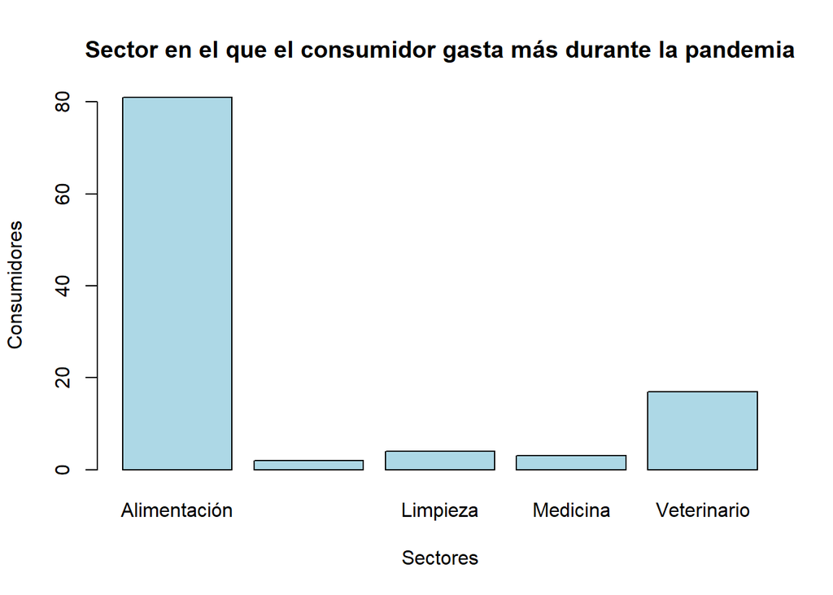

Calculamos los ejes de los intervalos de confianza del gráfico anterior:

| SectoresDP | lim_infG3 | mediaG3 | lim_supG3 |
| --- | --- | --- | --- |
| Alimentación | 117.40 | 138.16 | 158.92 |
| Juguetes y accesorios | 84.42 | 133.34 | 182.26 |
| Limpieza | 62.18 | 79.91 | 97.64 |
| Medicina | 25.16 | 38.30 | 51.44 |
| Veterinario | 67.90 | 84.95 | 102.00 |

Observaciones: Los 2 sectores principales donde se gasta más dinero tanto antes como durante la pandemia son Alimentación y Veterinario, siendo por mucho el de alimentación el de mayor gasto. Sin embargo, durante la pandemia los resultados dan a observar que han bajado el gasto en Veterinario y han aumentado el de Alimentación. Los sectores de limpieza, medicina y juguetes y accesorios no son sectores en el que la mayoría de los encuestados gaste más. El sector de juguetes y accesorios se mantuvo constante mientras que los sectores de Limpieza y medicina no tuvieron cambios relevantes.

Utilizaremos el gráfico de cajas y bigotes para comparar los dos sectores con más ingresos antes y durante la pandemia.

**Veterinario**

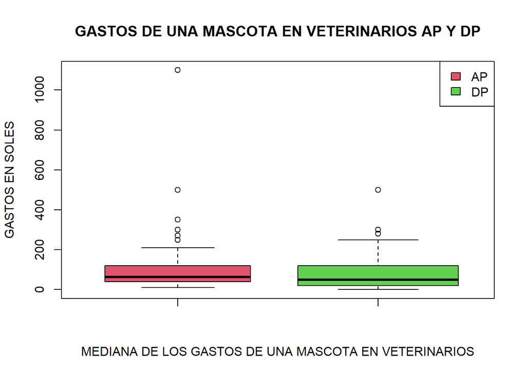

Calculamos los ejes de los intervalos de confianza para el sector veterinario:

| i | lim_infG4 | mediaG4 | lim_supG4 |
| --- | --- | --- | --- |
| Antes de Pandemia | 79.06 | 108.69 | 138.32 |
| Después de Pandemia | 67.90 | 84.95 | 102.00 |

**Alimentación**

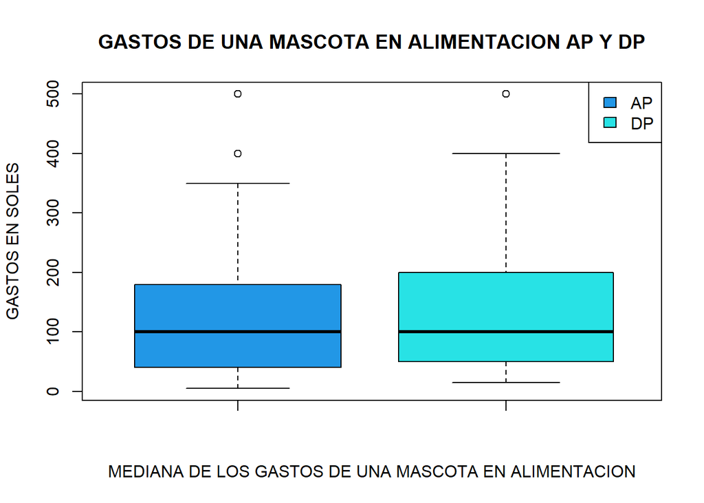

Calculamos los ejes de los intervalos de confianza para el sector alimenticio:

| i | lim_infG5 | mediaG5 | lim_supG5 |
| --- | --- | --- | --- |
| Antes de Pandemia | 105.34 | 124.97 | 144.60 |
| Después de Pandemia | 117.40 | 138.16 | 158.92 |

Observaciones:

- Comparando los gráficos de antes y después de la pandemia: En ambos gráficos el rango intercuartil tiene un ancho similar por lo que podemos asumir que la concentración de datos no varía demasiado. Asimismo, vemos que ambas gráficas presentan valores atípicos.
- Gracias a estos dos boxplots notamos que no son todas proporciones directas, la mediana de los gastos en el veterinario disminuyo ligeramente, en cambio, la de la alimentación se mantuvo.

## 7.3. Identificar las marcas con mayor posición en el mercado

**Antes de la pandemia**

Alimentos

| Acana | Britt Care | Canbo | CatChow | Dog Chow | Ducca | Friskis | Hill’s | Kanino |
| --- | --- | --- | --- | --- | --- | --- | --- | --- |
| 1 | 1 | 8 | 4 | 7 | 1 | 2 | 5 | 2 |

| michicat | Mimaskot | Mio Cane | No tengo una marca en específico | Nutram | Pro Plan | Purina | Ricocan | Ricocat | Sera |
| --- | --- | --- | --- | --- | --- | --- | --- | --- | --- |
| 1 | 17 | 1 | 36 | 2 | 2 | 1 | 37 | 2 | 1 |

Juguetes

| Kong | No tengo una marca en específico |
| --- | --- |
| 1 | 98 |

Limpieza

| Ascat | Dokki | Econo Arena | Klin Kat | No tengo una marca en específico | Scooby Doo Pet | Sera | Vetinex |
| --- | --- | --- | --- | --- | --- | --- | --- |
| 1 | 1 | 1 | 2 | 90 | 1 | 1 | 1 |

Medicamentos

| Bravecto | No necesita medicamentos | No tengo una marca en específico | Sera |
| --- | --- | --- | --- |
| 1 | 67 | 31 | 1 |

**Durante la pandemia**

Alimentos

| Acana | Brit | Britt Care | Canbo | CatChow | Comida Barf | Dog Chow | Ducca | Hill’s |
| --- | --- | --- | --- | --- | --- | --- | --- | --- |
| 1 | 2 | 1 | 10 | 5 | 1 | 7 | 1 | 9 |

| Kanino | Michicat | Mimaskot | Miocane | No tengo una marca en específico | Nutram | Pro Plan | Purina |
| --- | --- | --- | --- | --- | --- | --- | --- |
| 2 | 2 | 12 | 1 | 35 | 3 | 5 | 1 |

| Ricocan | Ricocat | Sera | Thor | Vet Life | Whiskas | NA | NA |
| --- | --- | --- | --- | --- | --- | --- | --- |
| 39 | 3 | 1 | 1 | 1 | 6 | NA | NA |

Juguetes

| No les gustan los juguetes | No tengo una marca en específico |
| --- | --- |
| 1 | 105 |

Limpieza

| Dokki | Econo Arena | hartz | Klin Kat | No tengo una marca en específico | Vetinex |
| --- | --- | --- | --- | --- | --- |
| 1 | 1 | 1 | 1 | 102 | 1 |

Medicamentos

| Bravecto | No necesita medicamentos | No tengo una marca en específico | Sera |
| --- | --- | --- | --- |
| 1 | 68 | 36 | 1 |

Observaciones: Antes de la pandemia, en el caso de alimentación, se nota una tendencia de preferir Ricocan, las marcas Mimaskot,Canbo y Hills también sobresalen pero en menor medida. Mientras que para juguetes, limpieza y medicina, la marca es indiferente. Durante la pandemia, las tendencias se mantienen, aparentemente esta situación no afectó directamente el consumo de las marcas de los alimentos de las mascotas. A partir de esto plantemos la hipótesis de que las marcas sobresalientes han bajado sus precios o los han mantenido durante la pandemia, por esto la preferencia y acogida.

## 7.4. Establecer los sectores del mercado con mayor dificultad para brindar sus servicios y/o productos

Antes de la pandemia

| Alimentos | Juguetes y accesorios | Limpieza | Medicina | No tuve dificultades | Veterinario |
| --- | --- | --- | --- | --- | --- |
| 5 | 2 | 5 | 8 | 81 | 7 |

Durante la pandemia

| Alimentos | Juguetes y accesorios | Limpieza | Medicina | No tengo dificultades | Veterinario |
| --- | --- | --- | --- | --- | --- |
| 12 | 6 | 8 | 12 | 159 | 17 |

Observaciones: Tanto antes como durante la pandemia, la mayoría de dueños no ven dificultad para conseguir servicios y/o productos. Y dentro de los que sí encuentran, no hay algún área que sobre salga entre las demás.

# **8.Relación entre variables**

## 8.1. Describir el crecimiento del mercado de mascotas

**Relación entre gastos y cantidad de mascotas**

*Antes de la pandemia*

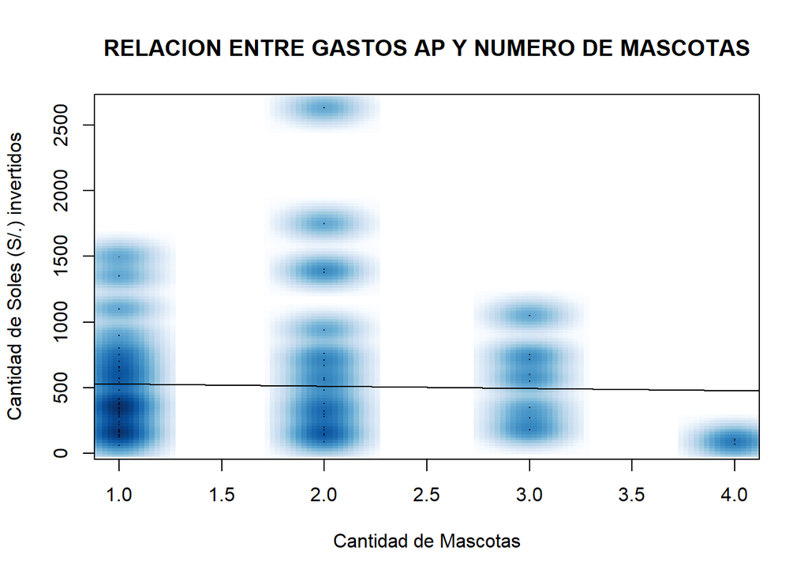

Calculamos los ejes de los intervalos de confianza:

| ejes | lim_infG6 | mediaG6 | lim_supG6 |
| --- | --- | --- | --- |
| Cantidad de Mascotas | 1.00 | 2.00 | 3.00 |
| Cantidad de Soles (S/.) invertidos | 412.34 | 513.48 | 614.62 |

*Durante de la pandemia*

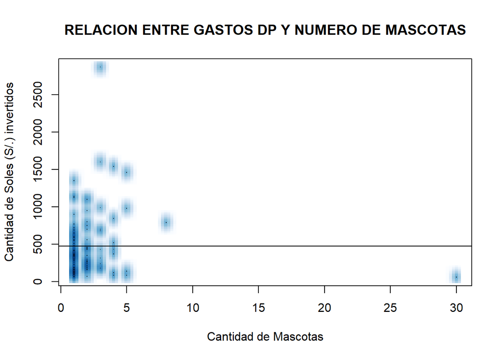

Calculamos los ejes de los intervalos de confianza:

| ejes | lim_infG7 | mediaG7 | lim_supG7 |
| --- | --- | --- | --- |
| Cantidad de Mascotas | 1.00 | 2.00 | 3.00 |
| Cantidad de Soles (S/.) invertidos | 397.45 | 481.46 | 565.47 |

Observaciones:

- Como se ha visto en la “P1”, antes y durante la pandemia, se puede observar que le número de mascotas y el costo total tiene un comportamiento directamente proporcional positivo. Sin embargo, al llegar a la cantidad de 151 encuestados el comportamiento de las gráficas es ligeramente negativo, es decir, ligeramente inversamente proporcional. Es por ello, que la hipótesis sería que a mayor cantidad de mascotas que los costos para mantenerlos pueden ser menores al solo tener una cantidad reducida. Esto podría darse debido a la compra de objetos al por mayor o de objetos más asequibles/económicos.
- Cabe resaltar que se observan valores atípicos.

## 8.2. Determinar la relación entre tiempo dedicado a la mascota con el dinero invertido en ellas

*Antes de la pandemia*

| Mayor de 4 AP | Menor de 4 AP |
| --- | --- |
| 34.44444 | 65.55556 |

*Durante de la pandemia*

| Mayor de 4 DP | Menor de 4 DP |
| --- | --- |
| 55.55556 | 44.44444 |

Observaciones: El porcentaje de personas que pasa más de 4 horas con su mascota aumento.

*Antes de la pandemia*

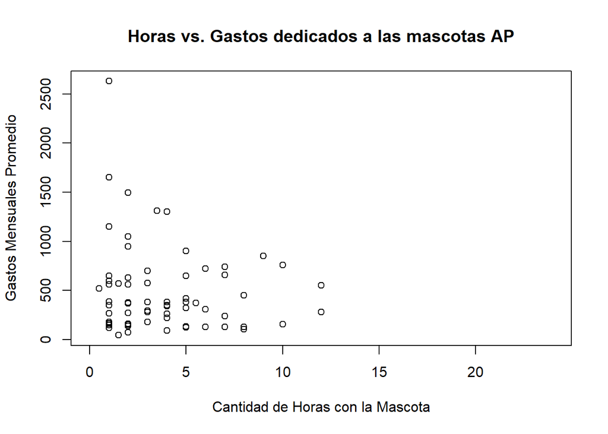

correlacion

```
## [1] -0.1212523
```

Calculamos los ejes de los intervalos de confianza:

| ejesG8 | lim_infG8 | mediaG8 | lim_supG8 |
| --- | --- | --- | --- |
| Cantidad de Horas con la Mascota | 3.4 | 4.17 | 4.94 |
| Gastos Mensuales Promedio | 385.0 | 481.50 | 578.00 |

*Durante la pandemia*

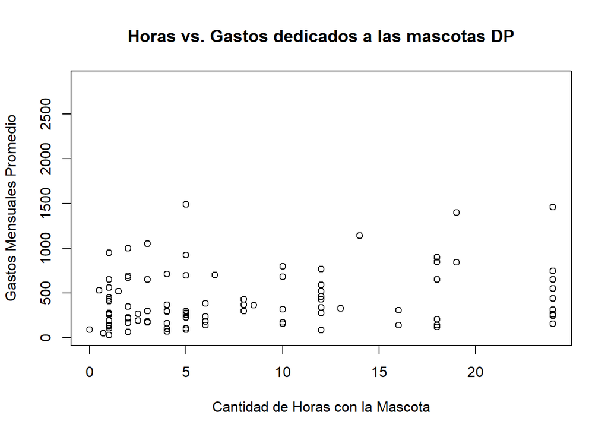

correlacion

```
## [1] 0.2419658
```

Calculamos los ejes de los intervalos de confianza:

| ejesG8 | lim_infG9 | mediaG9 | lim_supG9 |
| --- | --- | --- | --- |
| Cantidad de Horas con la Mascota | 6.67 | 8.14 | 9.61 |
| Gastos Mensuales Promedio | 360.19 | 439.26 | 518.33 |

Observaciones: Como podemos ver la correlacion de la gráfica “Antes de la pandemia” es negativa, lo que significa que la relación entre estas variables es inversa, pero por su modulo la relación entre las dos es baja. Esto se puede justificar a que antes las actividades diarias se realizaban fuera de la casa, por lo que pasar tiempo con tu mascota era algo limitado. Asimismo, la siguiente gráfica de “Después de la pandemia” posee una correlacion positiva, pero con una magnitud baja, lo que justifica la dispersión de los puntos. Además, el cambio signo se puede justificar con que la pandemia limito su libre tránsito a la mayoría de los encuestados provocando que se queden en sus casas y disfruten el tiempo con sus mascotas.Por lo que la hipótesis sería que cuando se vuelva a la nueva normalidad, la correlacion vuelva a tener una tendencia negativa, porque ya no se pasa tanto tiempo en casa, aunque las nuevas modalidades como el teletrabajo va a influir en la magnitud de la nueva correlacion

# **9. Probabilidades**

Podemos modelar estas variables con Bernoulli donde sí tiene mascota(s) en un éxito y donde no tiene mascota(s) es un fracaso

*Probabilidad de tener mascotas antes de la pandemia*

| No | Sí |
| --- | --- |
| 0.3421 | 0.6579 |

*Probabilidad de tener mascotas durante la pandemia*

| No | Sí |
| --- | --- |
| 0.2961 | 0.7039 |

Observaciones: Tomando en cuenta la tablas de probabilidades para la variables AP_ESTADO y DP_NUM_MASQ, si escogemos al azar una persona los más probable es que tenga mascota tanto antes de la pandemia como ahora. Asimismo es aún más probable que tenga mascota ahora.

*Probabilidad de tener mascota*

| / | No | Sí |
| --- | --- | --- |
| No | 0.2237 | 0.1184 |
| Sí | 0.0724 | 0.5855 |

*Probabilidad de que tenga mascotas antes y ahora*

$$P(Sí_A\cap Sí_D)=0.5855$$

*Probabilidad de que tenga mascotas solo antes*

$$P(Sí_A)-P(Sí_A\cap Sí_D)=0.6579-0.5855=0.0724$$

Observamos que la probabilidad de adquirir una mascota durante la pandemia es mayor que adquirir la mascota antes de la pandemia

## 9.2. Probabilidad del sector con mayor gasto

*Antes de la pandemia*

| Alimentación | Juguetes y accesorios | Limpieza | Medicina | Veterinario |
| --- | --- | --- | --- | --- |
| 0.66 | 0.02 | 0.03 | 0.02 | 0.27 |

*Durante la pandemia*

| Alimentación | Juguetes y accesorios | Limpieza | Medicina | Veterinario |
| --- | --- | --- | --- | --- |
| 0.757 | 0.0187 | 0.0374 | 0.028 | 0.1589 |

## 9.3. Probabilidad del tipo de mascota

*Antes de la pandemia*

| Canario | Cuyes | Gato | Loro | Peces | Perro |
| --- | --- | --- | --- | --- | --- |
| 0.0252 | 0.0168 | 0.2269 | 0.0084 | 0.0252 | 0.6975 |

*Durante la pandemia*

| Canario | Cuyes | Gato | Loro | Peces | Perro |
| --- | --- | --- | --- | --- | --- |
| 0.024 | 0.016 | 0.208 | 0.008 | 0.024 | 0.72 |

## 9.4. Probabilidad del sector con mayores problemas para brindar productos y/o servicios

*Antes de la pandemia*

| Alimentos | Juguetes y accesorios | Limpieza | Medicina | No tuve dificultades | Veterinario |
| --- | --- | --- | --- | --- | --- |
| 0.0463 | 0.0185 | 0.0463 | 0.0741 | 0.75 | 0.0648 |

*Durante la pandemia*

| Alimentos | Juguetes y accesorios | Limpieza | Medicina | No tengo dificultades | Veterinario |
| --- | --- | --- | --- | --- | --- |
| 0.0561 | 0.028 | 0.0374 | 0.0561 | 0.743 | 0.0794 |

## 9.5. Gastos mayores al promedio

“Los peruanos se preocupan cada vez más por sus mascotas, lo que suma en mayor medida su canasta familiar, gastando entre S/ 200 y S/ 300 por mes en promedio en el cuidado de su mascota.”según el mentor de la Incubadora Innova ESAN, [*Guillermo Vargas*](https://lacamara.pe/cuanto-gastan-los-peruanos-en-el-cuidado-de-sus-mascotas/).

```
## [1] 0.3092
```

# **10. Variables Aleatorias Discretas**

Asumimos que las siguientes variables se crearon aleatoriamente.

[output not shown]

## 10.1. Ejemplos del empleo de los modelos

A partir del modelo de Bernoulli calculamos la Varianza poblacional de dueños de mascotas para antes y durante la pandemia
$$Var(X)=p(1−p)$$

**Sector en el que gastan más** Sabiendo que el éxito es que gasten más en el sector de alimentación. La probabilidad de que el éxito ocurra menos de 100 veces en un ensayo que ocurre 151 veces es *Antes de la pandemia*

```
## [1] 0.5538
```

*Durante la pandemia*

```
## [1] 0.0055
```

Observación sobre ambos ejemplos: Asumimos que la encuesta y el ensayo del ejemplo se dan bajo las mismas condiciones de probabilidad.

# **11. Pruebas de hipótesis**

Observaciones: Las variables sobre los gastos, es decir, el dinero invertido en las mascotas con respecto a los sectores del mercado (Alimentación, Veterinario, Medicina, entre otros) es una variable continua pues los gastos están representados en soles con decimales. Asimismo, la variable que expresa las horas dedicadas a las mascotas es continua pues los dueños no van a pasar horas exactas con sus mascotas necesariamente.

## 11.1. Hipótesis 1

**Realizamos la prueba de hipótesis:**

Para esta hipótesis se evaluará la diferencia del dinero invertido en la alimentación de las mascotas antes y durante la pandemia.

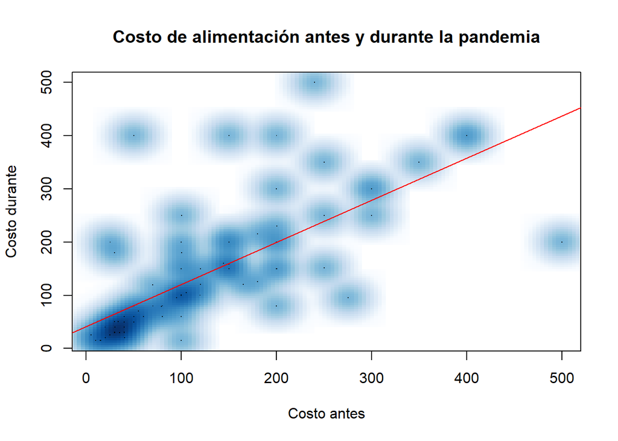

- **H0:** El aumento en soles de los gastos en alimentación de una mascota es menor igual que 25 soles mensuales

H0: $\mu <= 25$

- **Ha:** El aumento en soles de los gastos en alimentación de una mascota es mayor que 25 soles mensuales

Ha: $\mu > 25$

**Hallamos los intervalos de rechazo:**

Calculamos los límites por la izquierda y derecha, respectivamente.

```
## [1] 26.77879
```

Por lo tanto, el intervalo de nuestra región de rechazo es:
$$[26.78,+∞[$$

Debido a que 25 se no se encuentra dentro de la región de rechazo no se rechaza H0 pues encontramos suficiente evidencia a su favor con una significancia del 0.05.

**Realizamos la prueba de hipótesis unilateral:**

Hallamos el valor crítico:

```
## [1] 1.662765
```

Hallamos el valor estadístico:

```
## [1] -1.041339
```

Hallamos el p-valor:

```
## [1] 0.8496984
```

Obtenemos:

- **valor crítico (tc):** 1.663
- **valor estadístico (t):** -1.041
- **p-value:** 0.8497

Utilizando la función t.test() para corroborar nuestros datos, tenemos:

```
##
##  One Sample t-test
##
## data:  dif1
## t = -1.0413, df = 86, p-value = 0.8497
## alternative hypothesis: true mean is greater than 25
## 95 percent confidence interval:
##  1.313998      Inf
## sample estimates:
## mean of x
##  15.87862
```

Tenemos una cola hacia la derecha y nuestro valor crítico es mayor que el valor estadístico por lo que no rechazamos la hipótesis nula. El p-value nos muestra que tan probable es que ocurra nuestra hipótesis, por lo que nos servirá de complemento a nuestra conclusión. Nuestro p-value es mayor que la significancia por lo que corrobora que es más probable el no rechazo de la H0.

## 11.2. Hipótesis 2

Para esta hipótesis se evaluará la diferencia de los gastos mensuales en las mascotas antes y durante la pandemia.

```
## [1] "Antes de la pandemia"
```

| Min. | 1st Qu. | Median | Mean | 3rd Qu. | Max. | NA’s |
| --- | --- | --- | --- | --- | --- | --- |
| 60 | 180 | 380 | 513.4797 | 667.5 | 2630 | 78 |

```
## [1] "Durante la pandemia"
```

| Min. | 1st Qu. | Median | Mean | 3rd Qu. | Max. | NA’s |
| --- | --- | --- | --- | --- | --- | --- |
| 60 | 186.25 | 366.25 | 481.46 | 650 | 2865 | 54 |

- **H0:** El aumento entre los gastos mensuales de una mascota antes y durante la pandemia es menor o igual a 20 soles

H0: $\mu <= 20$

- **Ha:** El aumento entre los gastos mensuales de una mascota antes y durante la pandemia es mayor a 20 soles

Ha: $\mu > 20$

**Hallamos los intervalos de rechazo:**

Calculamos los límites por la izquierda y derecha, respectivamente.

```
## [1] 45.7335
```

Por lo tanto, el intervalo de nuestra región de rechazo es:

$$[45.73,+∞[$$
Debido a que de 20 no se encuentra dentro de la región de rechazo no se rechaza H0 pues encontramos suficiente evidencia con una significancia del 0.05.

**Realizamos la prueba de hipótesis unilateral:**

Hallamos el valor crítico:

```
## [1] 1.669013
```

Hallamos el valor estadístico:

```
## [1] -0.6192938
```

Hallamos el p-valor:

```
## [1] 0.7310562
```

Obtenemos:

- **valor crítico (tc):** 1.669
- **valor estadístico (t):** -0.619
- **p-value:** 0.731

Utilizando la función t.test() para corroborar nuestros datos, tenemos:

```
##
##  One Sample t-test
##
## data:  dif2
## t = -0.61929, df = 64, p-value = 0.731
## alternative hypothesis: true mean is greater than 20
## 95 percent confidence interval:
##  -109.0417       Inf
## sample estimates:
## mean of x
## -14.92308
```

Tenemos una cola hacia la derecha y nuestro valor crítico es mayor que el valor estadístico por lo que no rechazamos la hipótesis nula. El p-value nos muestra que tan probable es que ocurra nuestra hipótesis, por lo que nos servirá de complemento a nuestra conclusión. Nuestro p-value es mayor que la significancia por lo que corrobora que es más probable el no rechazo de la H0.

## 11.3. Hipótesis 3

Para esta hipótesis se evaluará la diferencia de las horas dedicadas a las mascotas antes y durante la pandemia

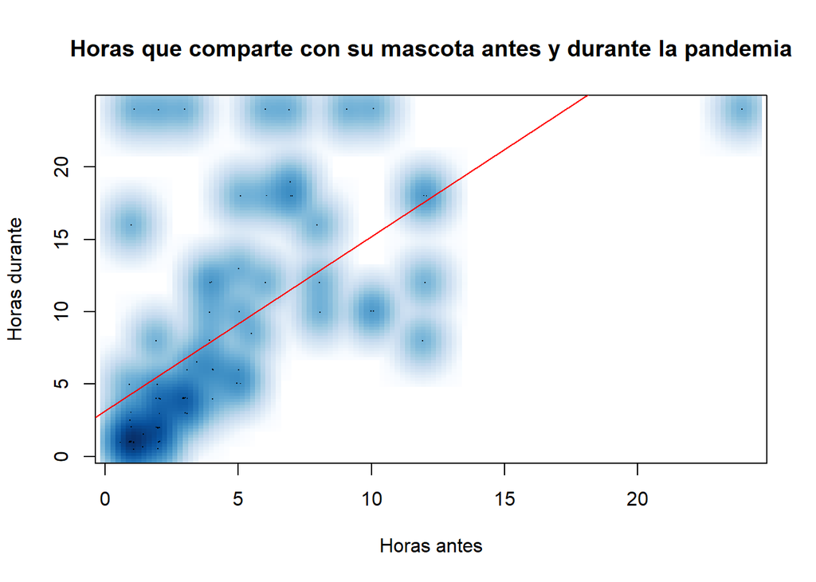

En esta gráfica se puede apreciar la relación existente entre las horas que pasan los dueños de las mascotas con las mismas antes y durante la pandemia. Dado que el intercepto de la función es aproximadamente 3, se puede inferir que este sería el valor promedio para el cambio de horas diarias. A su vez, la pendiente de la recta es positiva, por lo que esperamos que el cambio entre antes y durante la pandemia vaya en aumento. A partir de esto se plantean las siguientes hipótesis:

- **H0:** El aumento en horas es menor o igual 3 horas diarias

H0: $\mu <= 3$

Ha: $\mu > 3$

**Hallamos los intervalos de rechazo:**

Calculamos los límites por la izquierda y derecha, respectivamente.

```
## [1] 4.833582
```

Por lo tanto, el intervalo de nuestra región de rechazo es:

$$[4.83, ∞+[$$

En la cual encontramos que 3 no se encuentra dentro de la zona de rechazo, por lo que se puede considerar como un no rechazo a nuestra hipótesis nula. Entonces, de 3 horas a menos es un valor razonable para decir que representa el cambio de horas diarias que pasan los dueños con sus mascotas.

Hallamos el valor crítico:

```
## [1] 1.665151
```

Hallamos el valor estadístico:

```
## [1] 1.495835
```

Hallamos el p-valor:

```
## [1] 0.06939205
```

Obtenemos:

- **valor crítico (tc):** 1.665
- **valor estadístico (t):** 1.495
- **p-value:** 0.069

Utilizando la función t.test() para corroborar nuestros datos, tenemos:

```
##
##  One Sample t-test
##
## data:  dif3
## t = 1.4958, df = 76, p-value = 0.06942
## alternative hypothesis: true mean is greater than 3
## 95 percent confidence interval:
##  2.883574      Inf
## sample estimates:
## mean of x
##  4.028571
```

Tenemos una cola hacia la derecha y nuestro valor crítico es mayor que el valor estadístico por lo que no rechazamos la hipótesis nula. El p-value nos muestra que tan probable es que ocurra nuestra hipótesis, por lo que nos servirá de complemento a nuestra conclusión. Nuestro p-value es mayor que la significancia por lo que corrobora que es más probable el no rechazo de la H0.

# **12. Regresión**

## 12.1. Relación entre horas y gastos en mascotas

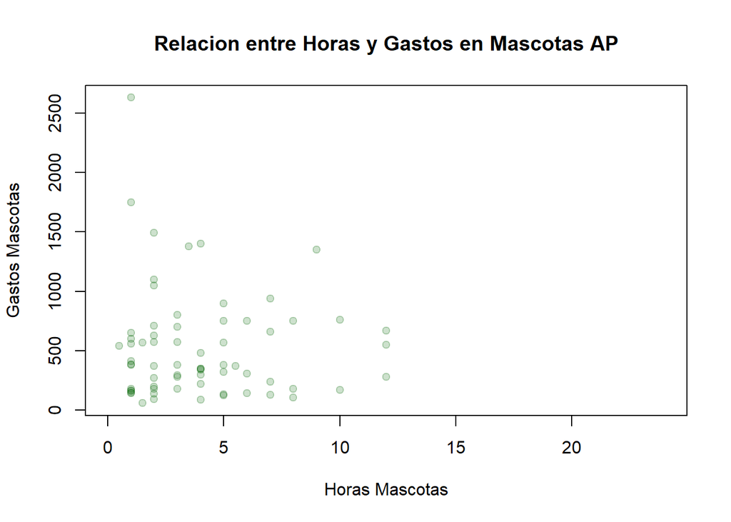

Descartamos la primera gráfica por su aspecto rápidamente

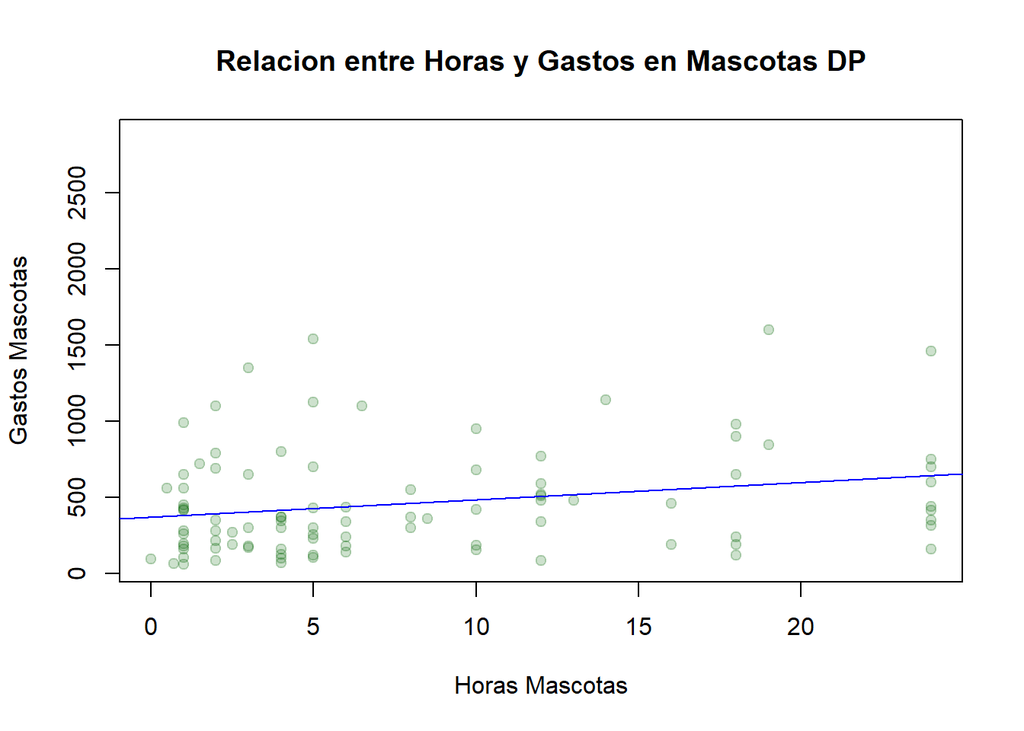

```
##
## Call:
## lm(formula = N ~ DF$DP_HORAS_MASQ)
##
## Residuals:
##     Min      1Q  Median      3Q     Max
## -483.43 -234.34  -96.01  159.36 1111.57
##
## Coefficients:
##                  Estimate Std. Error t value Pr(>|t|)
## (Intercept)       372.120     52.420   7.099 2.57e-10 ***
## DF$DP_HORAS_MASQ   11.263      4.803   2.345   0.0212 *
## ---
## Signif. codes:  0 '***' 0.001 '**' 0.01 '*' 0.05 '.' 0.1 ' ' 1
##
## Residual standard error: 342.6 on 92 degrees of freedom
##   (58 observations deleted due to missingness)
## Multiple R-squared:  0.0564, Adjusted R-squared:  0.04614
## F-statistic: 5.499 on 1 and 92 DF,  p-value: 0.02118
```

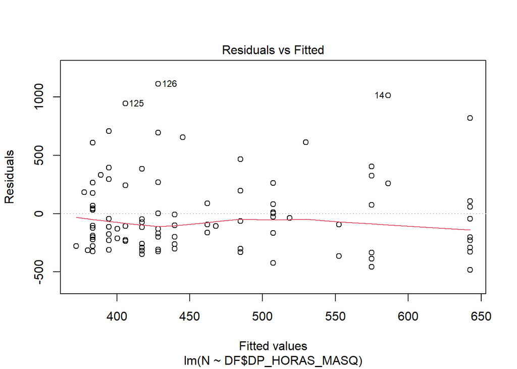

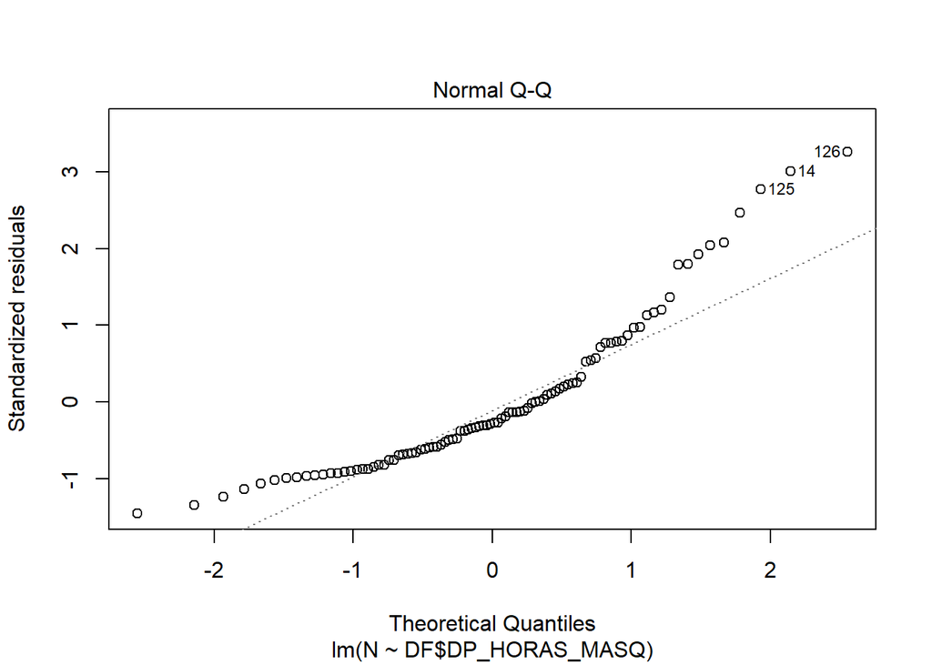

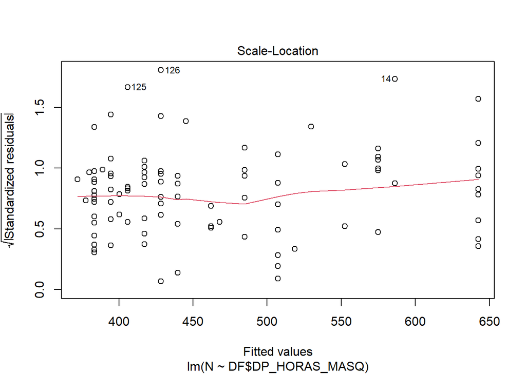

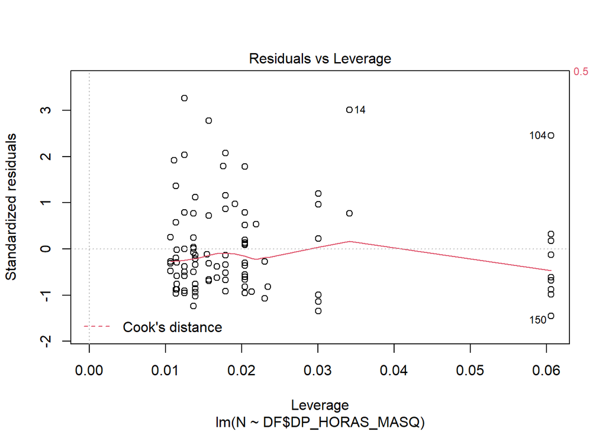

```
## [1] "P-value de Homocedasticidad:  3.58776086183106e-06"
## [1] "P-value de Correlación De Residuos:  0.626531747243285"
## [1] "Coeficiente de Pearson:  0.237483083082968"
## [1] "Coeficiente de determinacion:  0.0563982147505917"
## [1] "P-value de la evaluación de Shapiro-Wilk Con outliers:  6.18821507117557e-08"
```

Summary nos da a entender que existe correlación siempre cuando la significancia sea mayor a 2%, nos da un coeficiente de determinación muy cercana a 0 por lo que asumimos que esta relación entre variables es baja. Su intercepto es de 372.12 aproximadamente lo que nos indican que aún cuando pasan 0 horas juntos, gastan 372 soles en promedio en su mascota todos los meses, además la constante de la variable explicativa es 11.26 lo cual nos indica que por cada hora que pasemos con nuestra mascota aumentaremos en 11 soles el gasto que tendremos en ella.

## 12.2. Relación entre el gasto de alimentos antes y durante la pandemia

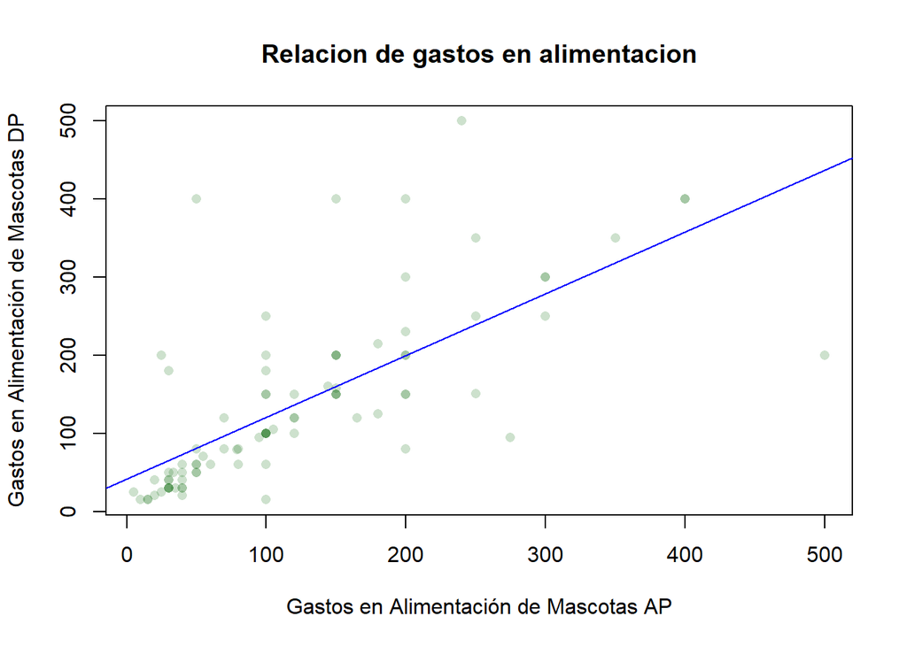

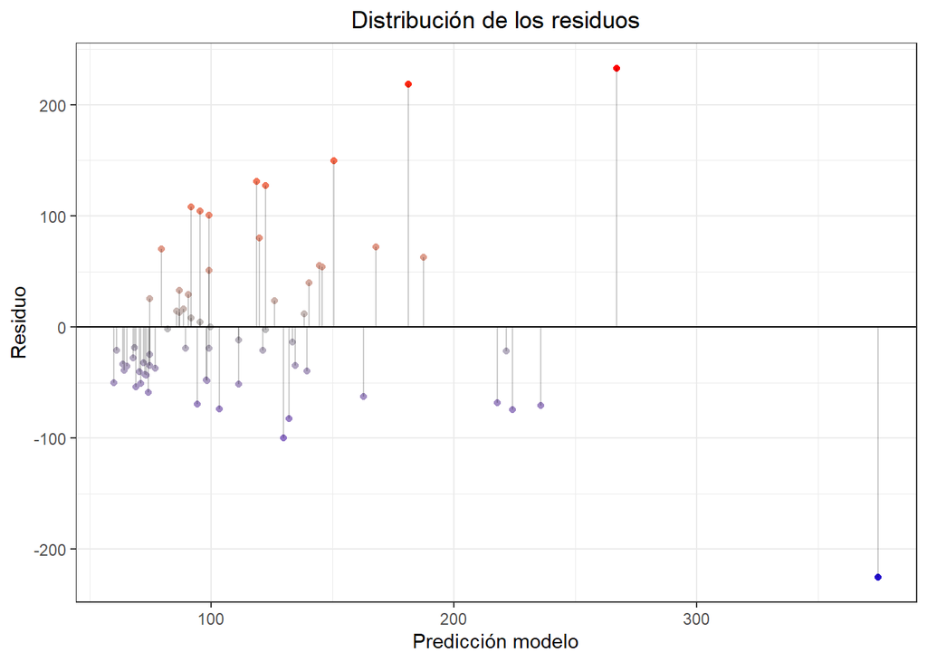

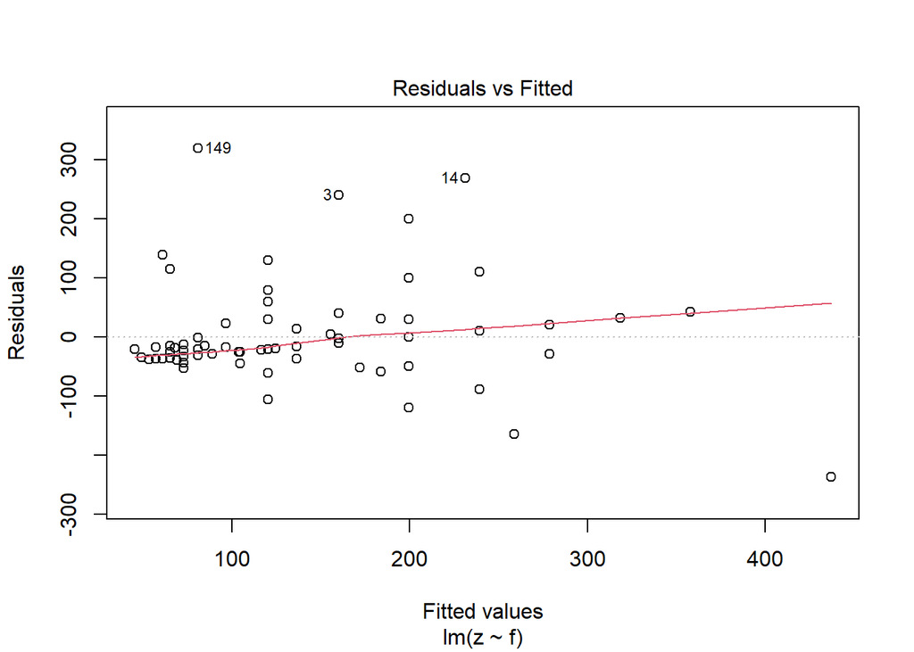

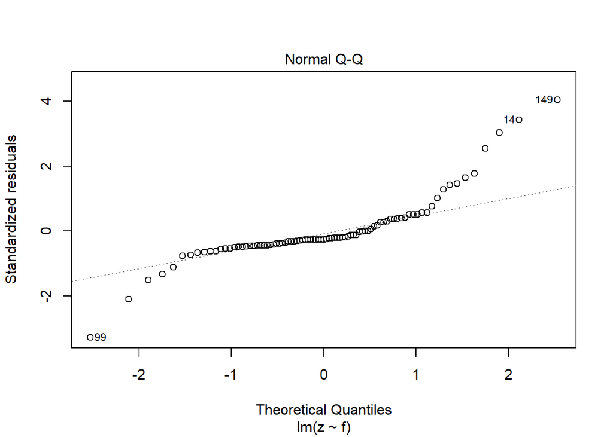

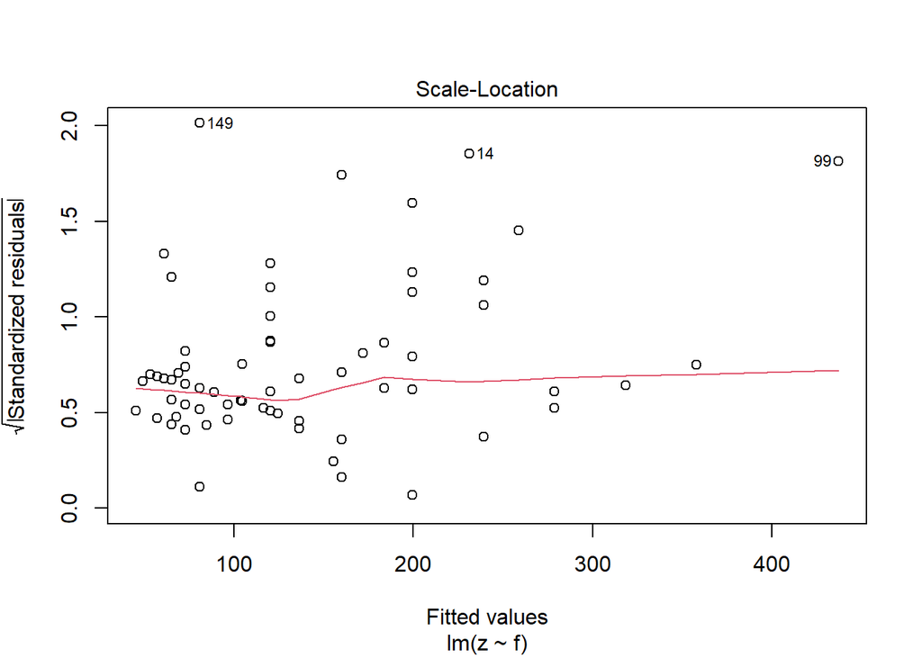

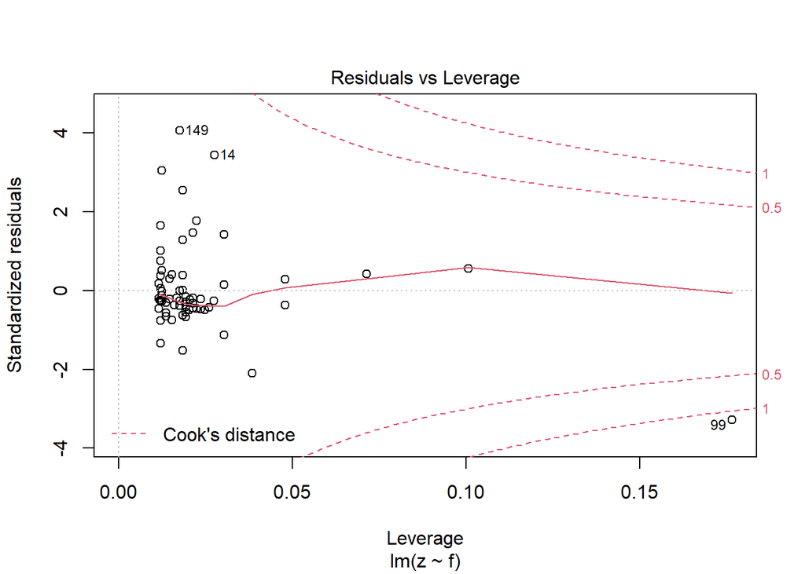

```
## [1] "P-value de Homocedasticidad:  0.0403663932996094"
## [1] "P-value de Correlación De Residuos:  0.356297336135457"
## [1] "Coeficiente de Pearson:  0.708566861600791"
## [1] "Coeficiente de determinacion:  0.502066997358794"
## [1] "P-value de la evaluación de Shapiro-Wilk Con outliers:  8.72827545123124e-06"
```

```
##
## Call:
## lm(formula = z ~ f, data = DF)
##
## Residuals:
##     Min      1Q  Median      3Q     Max
## -236.95  -35.17  -20.40   22.22  319.01
##
## Coefficients:
##             Estimate Std. Error t value Pr(>|t|)
## (Intercept) 41.44174   13.48179   3.074  0.00284 **
## f            0.79102    0.08544   9.258 1.62e-14 ***
## ---
## Signif. codes:  0 '***' 0.001 '**' 0.01 '*' 0.05 '.' 0.1 ' ' 1
##
## Residual standard error: 79.43 on 85 degrees of freedom
##   (65 observations deleted due to missingness)
## Multiple R-squared:  0.5021, Adjusted R-squared:  0.4962
## F-statistic: 85.71 on 1 and 85 DF,  p-value: 1.624e-14
```

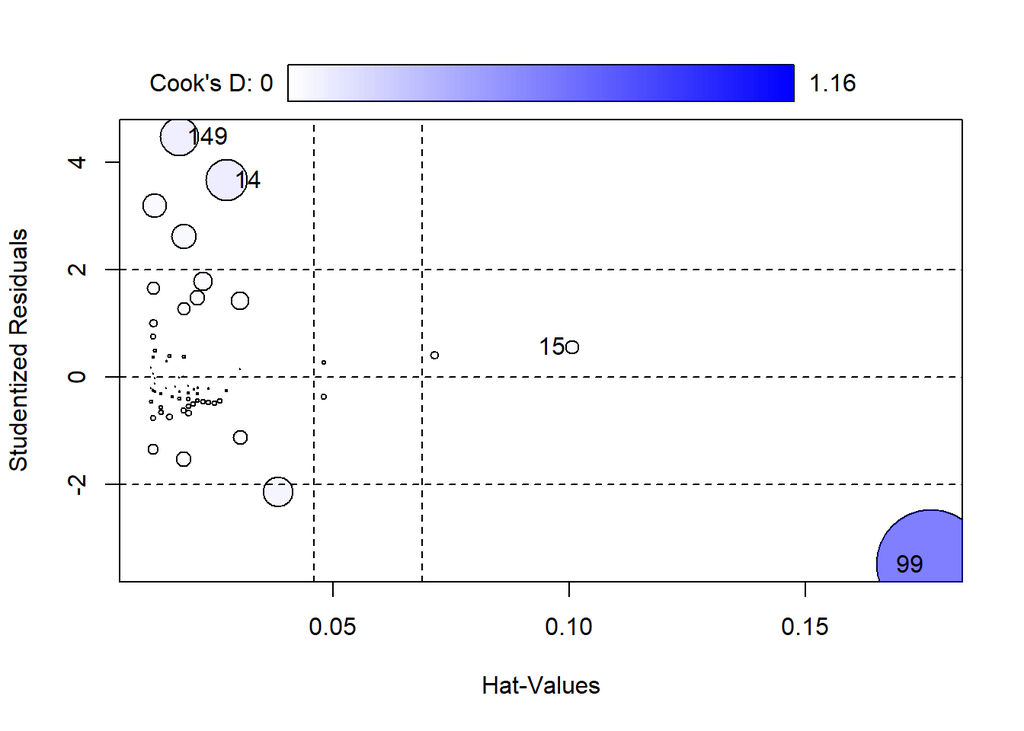

```
## [1] "y= 24.59  +  0.9 x"
## [1] "Coeficiente de determinacion sin puntos de influencia:  0.628000312627701"
```

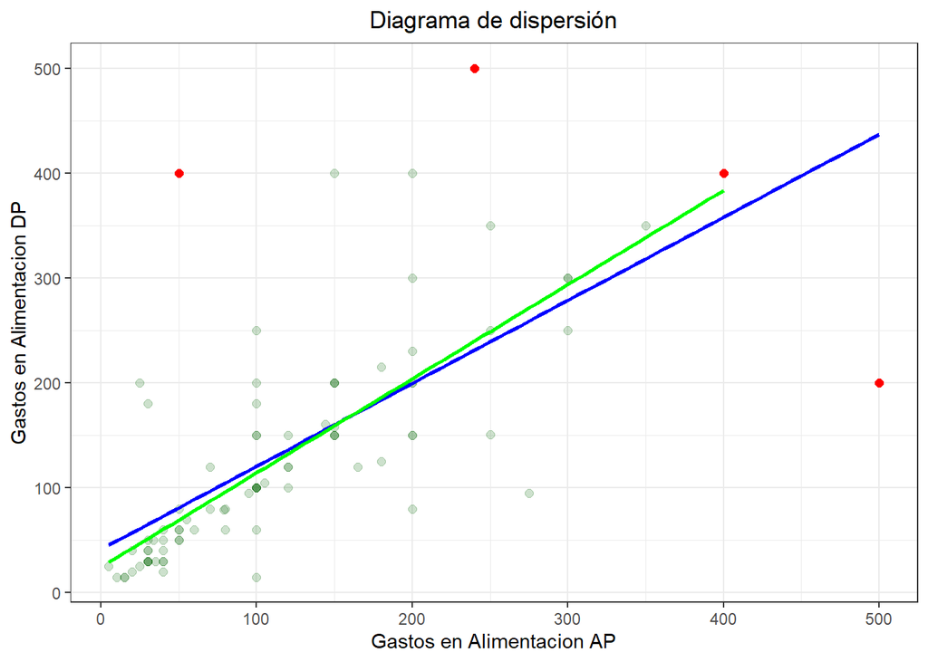

Podemos ver gracias a la función summary que nuestro intercepto rechaza la hipótesis nula de “este valor es 0”, aun así debemos recordar que hemos dejado apartados los valores “0” por lo que podemos decir que el intercepto, por si solo, no explica nada. Otro a p-value a destacar es el de la regresión en sí, rechaza fuertemente la hipótesis nula “No existe relación lineal entre las variables” por lo que procedemos a aceptar la relación.

**Miramos las gráficas**

En el gráfico de distribución de residuos, observamos que los errores están ubicados de manera aleatoria, aunque existe la presencia de outliers. Entonces, aceptamos la linealidad del modelo.

Tenemos gráficos de Homocedasticidad que indican pequeños rastros de problemas en la distribución de los datos.

Los puntos de influencia están presente, haciendo un efecto palanca en nuestro modelo, más adelante graficamos para ver la veracidad de esto.

En la gráfica qq podemos ver la influencia de los outliers en la relación de estas variables, se asume que son outliers pues los datos que se salen de la gráfica son los extremos y no forma una S tan curvada. Por otro lado, esta gráfica nos adelanta el rechazo de la distribución normal.

La interpretación del p-value de correlación de los residuos dada por la prueba Durbin y Watson nos da que la hipótesis nula no se rechaza pues p-value es mayor que 0.05, por lo que asumiremos que no hay relación entre estos.

El coeficiente de Pearson nos indica que estas variables se encuentran entre una relación positiva moderada.

Graficamos las dos regresiones, sin puntos de influencia y con puntos de influencia, nos damos cuenta que si influyen mucho y que pueden llegar a cambiar la correlacion.

Por la presencia de algunos outliers y puntos de influencia no hallamos una distribución normal pero tampoco hallamos una correlacion entre los residuos por lo que concluimos que esta relación puede ajustarse mediante un ajuste lineal estadístico dado un nivel de significancia del 5%.

## 12.3. Relación entre el gasto de limpieza antes y durante la pandemia

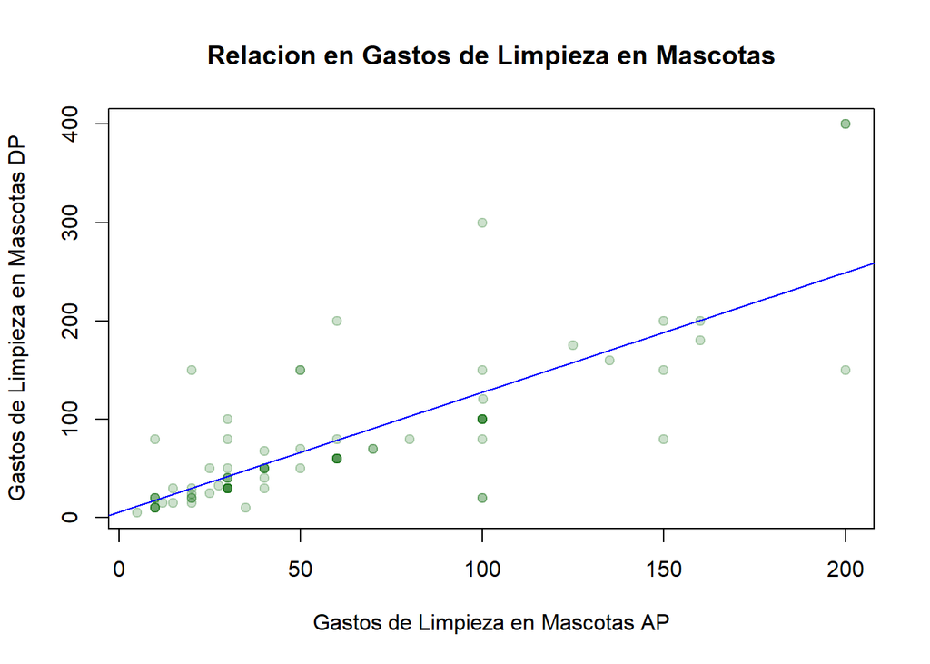

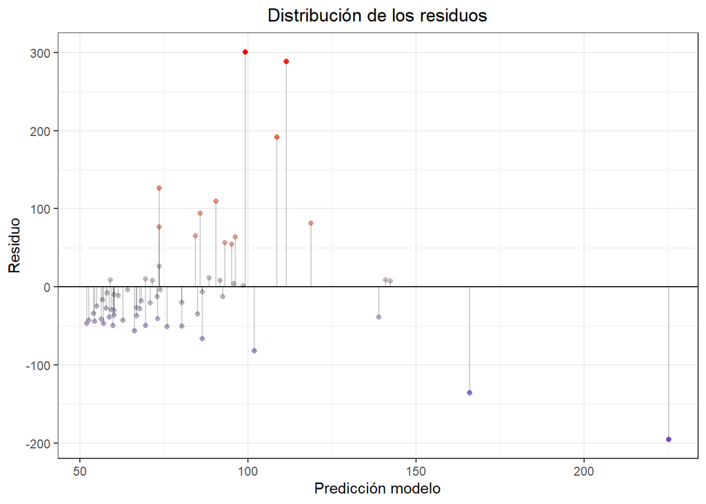

```
## [1] "P-value de Homocedasticidad:  0.00203056000856801"
## [1] "P-value de Correlación De Residuos:  0.725319430151637"
## [1] "Coeficiente de Pearson:  0.77306987825229"
## [1] "Coeficiente de determinacion:  0.597637036661011"
## [1] "P-value de la evaluación de Shapiro-Wilk Con outliers:  1.15992576910765e-07"
```

```
##
## Call:
## lm(formula = f ~ z, data = DF)
##
## Residuals:
##      Min       1Q   Median       3Q      Max
## -108.559  -18.722   -7.702    2.298  172.461
##
## Coefficients:
##             Estimate Std. Error t value Pr(>|t|)
## (Intercept)   5.4980     9.0862   0.605    0.547
## z             1.2204     0.1164  10.484 2.78e-16 ***
## ---
## Signif. codes:  0 '***' 0.001 '**' 0.01 '*' 0.05 '.' 0.1 ' ' 1
##
## Residual standard error: 50.51 on 74 degrees of freedom
##   (76 observations deleted due to missingness)
## Multiple R-squared:  0.5976, Adjusted R-squared:  0.5922
## F-statistic: 109.9 on 1 and 74 DF,  p-value: 2.784e-16
```

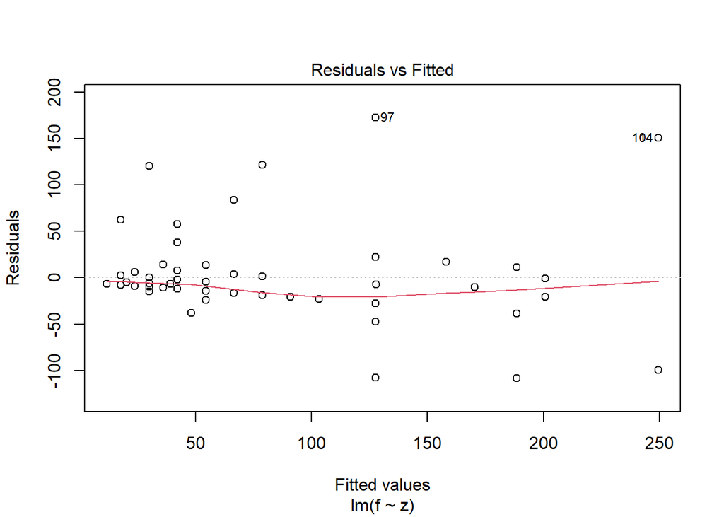

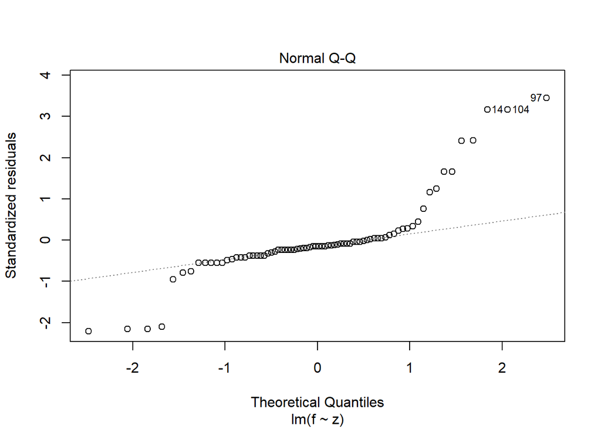

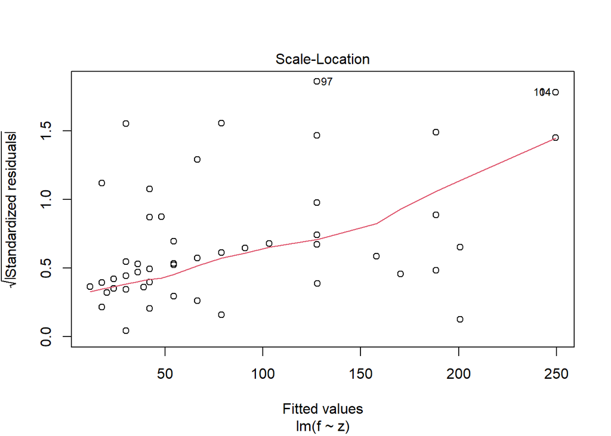

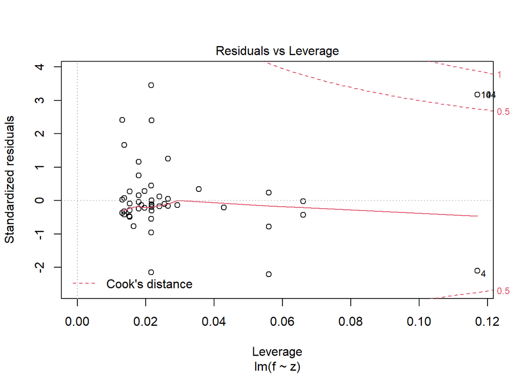

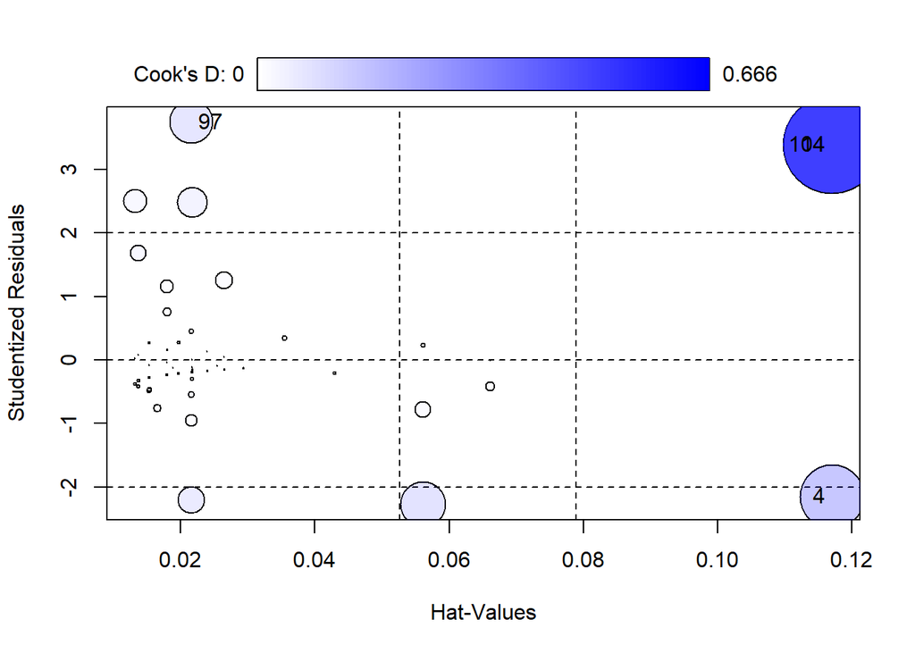

```
## [1] "y= 16.39  +  0.92 x"
## [1] "Coeficiente de determinacion sin puntos de influencia:  0.53908816413638"
```

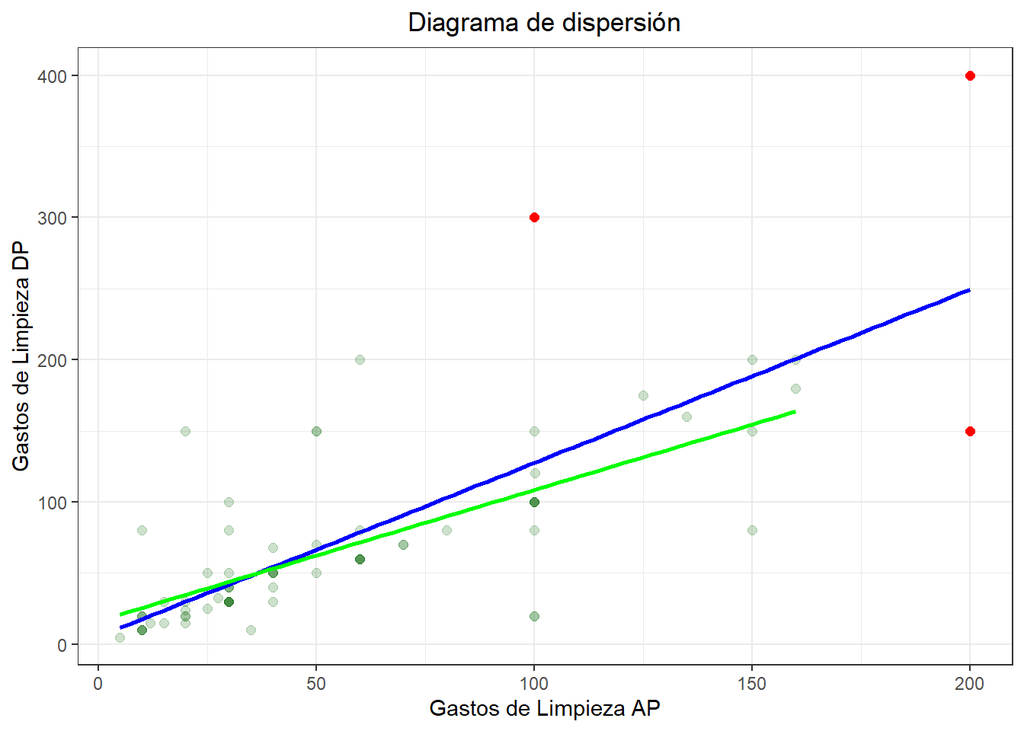

Al trabajar con sisgnificancia del 5% la funcion summary no rechaza la hipótesis nula del intercepto “este valor es 0” pero debemos recordar que hemos dejado apartados los valores “0” por lo que podemos decir que el intercepto, por si solo, no explica nada. Otro a p-value a destacar es el de la regresión en sí, rechaza fuertemente la hipótesis nula “No existe relación lineal entre las variables” por lo que procedemos a aceptar la relación.

**Miramos los gráficos**

En el gráfico de distribución de residuos, observamos que los errores no presentan una estructura, es aleatoria, aunque nos preocupa la presencia de los puntos en la parte media inferior izquierda del gráfico. Aceptamos la linealidad del modelo.

Tenemos gráficos de Homocedasticidad que indican indicios de problemas en la distribución de los datos.

Los puntos de influencia estan presente, haciendo un efecto palanca en nuestro modelo, más adelante graficamos para ver la veracidad de esto.

En la gráfica qq podemos ver la influencia de los outlier en la relación de estas variables, se asume que son outliers pues los datos que se salen de la gráfica son los extremos y no forma una S tan curvada. Por otro lado, esta gráfica nos adelanta el rechazo de la distribucion normal.

La interpretación del p-value de correlacion de los residuos dada por la prueba Durbin y Watson nos da que la hipótesis nula no se rechaza pues p-value es mayor que 0.05, por lo que asumiremos que no hay relación entre estos.

Nuestra ultima gráfica compara las regresiones con puntos de influencia y sin ellos, vemos que es significativo e importante.

Determinamos el coeficiente de Pearson y nos damos con una correlacion de 0.77 por lo que diremos que este ajuste lineal es medianamente fiable con poca homocedasticidad y sus residuos no están distribuidos de forma constante. Presenta una correlacion positiva fuerte teniendo como coeficiente que acompaña a la variable explicativa “1.2” con 0.1 de error.

# **13.Conclusiones**

- Con respecto al primer objetivo el número de dueños aumento con la pandemia al igual que el número de mascotas. Dentro de los nuevos dueños una gran cantidad adopto o compro más de una mascota.
- Con respecto al segundo objetivo a partir de lo analizado con los descriptores gráficos, tanto antes como durante la pandemia, se puede llegar a la conclusión que el sector en el que los dueños de mascotas gastan más es el de “Alimentación”.
- Con respecto al tercer objetivo los dueños gastaron menos en el sector de Medicina y Juguetes y accesorios. Durante la pandemia solo el sector de Medicina aumento sus ingresos.
- Con respecto al cuarto objetivo las marcas no son muy relevantes para los encuestados a la hora de conseguir bienes para sus mascotas, excepto por el sector alimenticio. En este sector la marcas favoritas de los consumidores son Ricocan, la cual es la más sobresaliente con una amplia diferencia y le siguen Mimaskot y Canbo con una menor relevancia.
- Con respecto al quinto objetivo a partir de la regresión lineal establezco para la relación entre horas y gastos en mascotas durante la pandemia el modelo y=372.120+11.263x y este explica el 5.64%. Asimismo, como pudimos observar en las gráficas de comparación, no había relación de las horas que pasan las personas con sus mascotas con el dinero que gastan en ellos antes de pandemia, sin embargo, durante pandemia la relación tuvo una correlación baja pues el coeficiente de Pearson solo era de 0.2 y en una escala de -1 a 1 eso, es cercano a 0, que indicaría que no explica nada.